# Modeling and prediction for movies

## Setup

### Load packages

```r
library(ggplot2)
library(dplyr)
library(statsr)
library(GGally)
library(Metrics)
```

### Load data

Make sure your data and R Markdown files are in the same directory. When loaded your data file will be called `movies`. Delete this note when before you submit your work.

```r
load("movies.Rdata")

movies %>% head(5)
```

```
## # A tibble: 5 x 32
##   title title_type genre runtime mpaa_rating studio thtr_rel_year thtr_rel_month
##   <chr> <fct>      <fct>   <dbl> <fct>       <fct>          <dbl>          <dbl>
## 1 Fill~ Feature F~ Drama      80 R           Indom~          2013              4
## 2 The ~ Feature F~ Drama     101 PG-13       Warne~          2001              3
## 3 Wait~ Feature F~ Come~      84 R           Sony ~          1996              8
## 4 The ~ Feature F~ Drama     139 PG          Colum~          1993             10
## 5 Male~ Feature F~ Horr~      90 R           Ancho~          2004              9
## # ... with 24 more variables: thtr_rel_day <dbl>, dvd_rel_year <dbl>,
## #   dvd_rel_month <dbl>, dvd_rel_day <dbl>, imdb_rating <dbl>,
## #   imdb_num_votes <int>, critics_rating <fct>, critics_score <dbl>,
## #   audience_rating <fct>, audience_score <dbl>, best_pic_nom <fct>,
## #   best_pic_win <fct>, best_actor_win <fct>, best_actress_win <fct>,
## #   best_dir_win <fct>, top200_box <fct>, director <chr>, actor1 <chr>,
## #   actor2 <chr>, actor3 <chr>, actor4 <chr>, actor5 <chr>, imdb_url <chr>, ...
```

## Part 1: Data

As per the dataset documentation, “*The data set is comprised of 651 randomly sampled movies produced and released before 2016*”. Therefore, as we have a random sample, we can generalize the data to other movies. But being an observational dataset, there’s no causality, only association possible.

One potential bias source is that the movies not present in the IMDB cannot be selected.

```r
# Dataset shape (rows, columns)
print( paste('This dataset has', dim(movies)[1], 'rows and', dim(movies)[2], 'columns.') )
```

```
## [1] "This dataset has 651 rows and 32 columns."
```

```r
# Types of each variable
str(movies)
```

```
## tibble [651 x 32] (S3: tbl_df/tbl/data.frame)
##  $ title           : chr [1:651] "Filly Brown" "The Dish" "Waiting for Guffman" "The Age of Innocence" ...
##  $ title_type      : Factor w/ 3 levels "Documentary",..: 2 2 2 2 2 1 2 2 1 2 ...
##  $ genre           : Factor w/ 11 levels "Action & Adventure",..: 6 6 4 6 7 5 6 6 5 6 ...
##  $ runtime         : num [1:651] 80 101 84 139 90 78 142 93 88 119 ...
##  $ mpaa_rating     : Factor w/ 6 levels "G","NC-17","PG",..: 5 4 5 3 5 6 4 5 6 6 ...
##  $ studio          : Factor w/ 211 levels "20th Century Fox",..: 91 202 167 34 13 163 147 118 88 84 ...
##  $ thtr_rel_year   : num [1:651] 2013 2001 1996 1993 2004 ...
##  $ thtr_rel_month  : num [1:651] 4 3 8 10 9 1 1 11 9 3 ...
##  $ thtr_rel_day    : num [1:651] 19 14 21 1 10 15 1 8 7 2 ...
##  $ dvd_rel_year    : num [1:651] 2013 2001 2001 2001 2005 ...
##  $ dvd_rel_month   : num [1:651] 7 8 8 11 4 4 2 3 1 8 ...
##  $ dvd_rel_day     : num [1:651] 30 28 21 6 19 20 18 2 21 14 ...
##  $ imdb_rating     : num [1:651] 5.5 7.3 7.6 7.2 5.1 7.8 7.2 5.5 7.5 6.6 ...
##  $ imdb_num_votes  : int [1:651] 899 12285 22381 35096 2386 333 5016 2272 880 12496 ...
```

[output cut: 18 more lines]

While I am sure we could explore this dataset in many ways, for the purpose of this project that is a Linear Regression Analysis, I will initially drop some columns that will not matter for the study. The variables dropped are: * actor1, actor2, actor3, actor4, actor5 * imdb_url and rt_url * studio * director

```r
# Drop variables and assign to a new dataset name to preserve the original data
movies2 <- movies %>%
  select( !c(actor1, actor2, actor3, actor4, actor5, director, imdb_url, rt_url, studio) )
```

## Part 2: Research question

The present study will perform a **Multiple Linear Regression Analysis**, seeking answer to the question:

### *What variables from the dataset can better explain the variance of the IMDB ratings?*

## Part 3: Exploratory data analysis

The first steps for a good exploratory analysis are to check the distribution of the data and the descriptive statistics.

```r
# Descriptive Statistics
summary(movies2)
```

```
##     title                  title_type                 genre        runtime
##  Length:651         Documentary : 55   Drama             :305   Min.   : 39.0
##  Class :character   Feature Film:591   Comedy            : 87   1st Qu.: 92.0
##  Mode  :character   TV Movie    :  5   Action & Adventure: 65   Median :103.0
##                                        Mystery & Suspense: 59   Mean   :105.8
##                                        Documentary       : 52   3rd Qu.:115.8
##                                        Horror            : 23   Max.   :267.0
##                                        (Other)           : 60   NA's   :1
##   mpaa_rating  thtr_rel_year  thtr_rel_month   thtr_rel_day    dvd_rel_year
##  G      : 19   Min.   :1970   Min.   : 1.00   Min.   : 1.00   Min.   :1991
##  NC-17  :  2   1st Qu.:1990   1st Qu.: 4.00   1st Qu.: 7.00   1st Qu.:2001
##  PG     :118   Median :2000   Median : 7.00   Median :15.00   Median :2004
##  PG-13  :133   Mean   :1998   Mean   : 6.74   Mean   :14.42   Mean   :2004
##  R      :329   3rd Qu.:2007   3rd Qu.:10.00   3rd Qu.:21.00   3rd Qu.:2008
##  Unrated: 50   Max.   :2014   Max.   :12.00   Max.   :31.00   Max.   :2015
##                                                               NA's   :8
##  dvd_rel_month     dvd_rel_day     imdb_rating    imdb_num_votes
##  Min.   : 1.000   Min.   : 1.00   Min.   :1.900   Min.   :   180
##  1st Qu.: 3.000   1st Qu.: 7.00   1st Qu.:5.900   1st Qu.:  4546
##  Median : 6.000   Median :15.00   Median :6.600   Median : 15116
##  Mean   : 6.333   Mean   :15.01   Mean   :6.493   Mean   : 57533
##  3rd Qu.: 9.000   3rd Qu.:23.00   3rd Qu.:7.300   3rd Qu.: 58301
##  Max.   :12.000   Max.   :31.00   Max.   :9.000   Max.   :893008
##  NA's   :8        NA's   :8
##          critics_rating critics_score    audience_rating audience_score
##  Certified Fresh:135    Min.   :  1.00   Spilled:275     Min.   :11.00
##  Fresh          :209    1st Qu.: 33.00   Upright:376     1st Qu.:46.00
##  Rotten         :307    Median : 61.00                   Median :65.00
##                         Mean   : 57.69                   Mean   :62.36
##                         3rd Qu.: 83.00                   3rd Qu.:80.00
##                         Max.   :100.00                   Max.   :97.00
##
##  best_pic_nom best_pic_win best_actor_win best_actress_win best_dir_win
##  no :629      no :644      no :558        no :579          no :608
##  yes: 22      yes:  7      yes: 93        yes: 72          yes: 43
##
##
##
##
##
##  top200_box
##  no :636
##  yes: 15
##
##
##
##
##
```

#### Let’s see the distributions now.

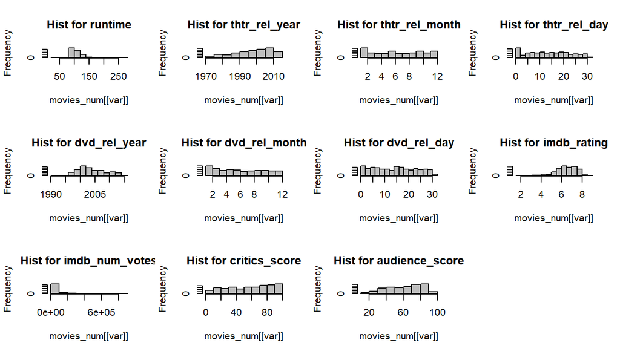

```r
# Selecting only numerical variables
movies_num <- select_if(movies2, is.numeric)

# Creating a figure for the plots
par(mfrow=c(3, 4))


# Plotting histograms
for (var in colnames(movies_num)){
  hist(movies_num[[var]], main=paste('Hist for', var), col='gray' )
}
```

After plotted all of the histograms, we see that most of the variables are skewed. There are no normally distributed variables.

In order to start thinking about the modeling, it is needed to plot the scatterplots and check the relationships between the variables.

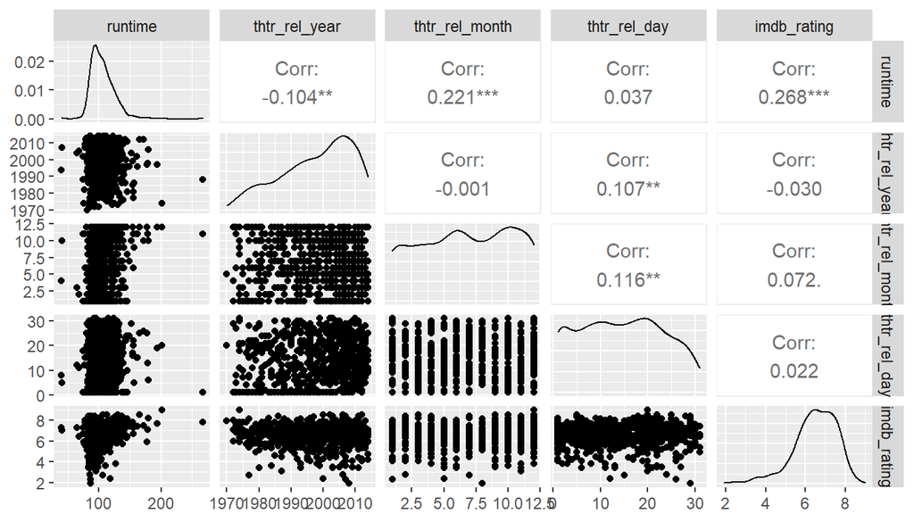

```r
# Plot scatterplots
ggpairs(movies_num[,c('runtime', 'thtr_rel_year', 'thtr_rel_month', 'thtr_rel_day','imdb_rating')])
```

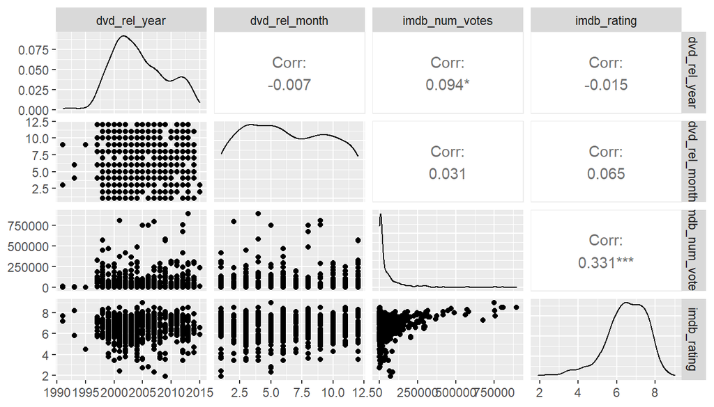

```r
ggpairs(movies_num[,c('dvd_rel_year', 'dvd_rel_month', 'imdb_num_votes','imdb_rating')])
```

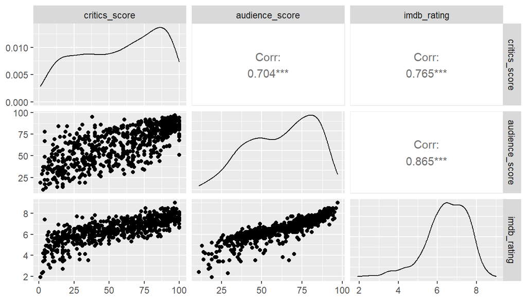

```r
ggpairs(movies_num[,c('critics_score', 'audience_score', 'imdb_rating')])
```

With the scatterplots on screen, they present that the highest correlations with the response variable *imdb_ratings* are the scores from other sources, such as *audience_score and critics_score*.

#### Does the genre interfere on the ratings?

As the ratings are skewed, we will prefer to use the median

```r
# Mean ratings by
movies2 %>%
  group_by(genre) %>%
  summarise(median_value = quantile(imdb_rating, 0.5),
            n = n(),
            mean = mean(imdb_rating)) %>%
  arrange(desc(median_value))
```

```
## # A tibble: 11 x 4
##    genre                     median_value     n  mean
##    <fct>                            <dbl> <int> <dbl>
##  1 Documentary                       7.6     52  7.65
##  2 Musical & Performing Arts         7.55    12  7.3
##  3 Drama                             6.8    305  6.67
##  4 Other                             6.8     16  6.63
##  5 Art House & International         6.5     14  6.61
##  6 Mystery & Suspense                6.5     59  6.48
##  7 Animation                         6.4      9  5.9
##  8 Action & Adventure                6       65  5.97
##  9 Horror                            5.9     23  5.76
## 10 Science Fiction & Fantasy         5.9      9  5.76
## 11 Comedy                            5.7     87  5.74
```

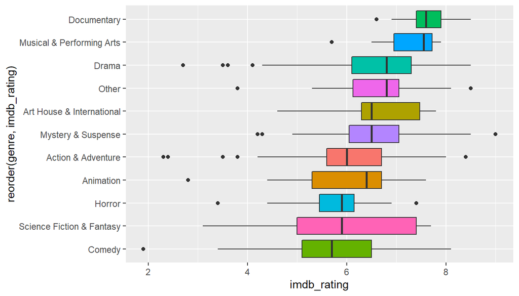

```r
# Boxplot Ratings by genre
ggplot(data=movies2, aes(y=reorder(genre,imdb_rating), x=imdb_rating) ) +
  geom_boxplot(aes(fill=genre), show.legend = FALSE)
```

But, can we say that those averages are statistically different?

```r
# ANOVA test for the genre means
anova_genre <- aov(imdb_rating ~ genre, data = movies2)
summary(anova_genre)
```

```
##              Df Sum Sq Mean Sq F value Pr(>F)
## genre        10  174.5  17.446   18.91 <2e-16 ***
## Residuals   640  590.4   0.922
## ---
## Signif. codes:  0 '***' 0.001 '**' 0.01 '*' 0.05 '.' 0.1 ' ' 1
```

With a P value below the significance level of 0.05, we reject the null hypothesys and confirm that there is significant difference by genre.

Before we go to the modeling, let’s get rid of some missing values, identified in the stats.

```r
# Check for total NAs
sum(is.na(movies2))
```

```
## [1] 25
```

As there are only 25, I will just go ahead and remove them. it is just 3% of the data

```r
# Remove NAs
movies2 <- na.omit(movies2)
```

## Part 4: Modeling

In this section, we will start to model the problem using linear regression.

We know that the best correlated variables are *audience_score, critics_score*. We also know that *genre* makes difference in the ratings, thus I will begin with those variables and build from them.

```r
# Initial model
model1 <- lm(imdb_rating ~ audience_score + critics_score + genre, data=movies2)

summary(model1)
```

```
##
## Call:
## lm(formula = imdb_rating ~ audience_score + critics_score + genre,
##     data = movies2)
##
## Residuals:
##      Min       1Q   Median       3Q      Max
## -2.41382 -0.21245  0.04164  0.28329  1.16637
##
## Coefficients:
##                                  Estimate Std. Error t value Pr(>|t|)
## (Intercept)                     3.6964115  0.0819704  45.094  < 2e-16 ***
## audience_score                  0.0343525  0.0013458  25.525  < 2e-16 ***
## critics_score                   0.0105927  0.0009559  11.081  < 2e-16 ***
## genreAnimation                 -0.4735190  0.1692520  -2.798  0.00530 **
## genreArt House & International  0.2252294  0.1450609   1.553  0.12101
## genreComedy                    -0.1887325  0.0784810  -2.405  0.01647 *
## genreDocumentary                0.1851475  0.0967460   1.914  0.05611 .
## genreDrama                      0.0726158  0.0674299   1.077  0.28193
## genreHorror                     0.0246026  0.1161995   0.212  0.83239
## genreMusical & Performing Arts  0.0375621  0.1522032   0.247  0.80515
## genreMystery & Suspense         0.2793802  0.0866169   3.225  0.00132 **
## genreOther                     -0.0432402  0.1338846  -0.323  0.74683
## genreScience Fiction & Fantasy -0.0891595  0.1784214  -0.500  0.61745
## ---
## Signif. codes:  0 '***' 0.001 '**' 0.01 '*' 0.05 '.' 0.1 ' ' 1
##
## Residual standard error: 0.4743 on 629 degrees of freedom
## Multiple R-squared:  0.8088, Adjusted R-squared:  0.8051
## F-statistic: 221.7 on 12 and 629 DF,  p-value: < 2.2e-16
```

That is a good start. The R² was 81% from start. Audience and critics scores are very important for the model and help to explain the variance. Notice that the genre brings some significant variables and some that are not.

Let’s use the forward technique and add some new variables, aiming to increase our R²-Adjusted. Some other variables to be used are using the correlation criterium. The stronger, the better, so *imdb_num_votes, runtime, thtr_rel_month and thtr_rel_year*

```r
# Added imdb_num_votes to the model
model2 <- lm(imdb_rating ~ audience_score + critics_score + genre + imdb_num_votes, data=movies2)
summary(model2)
```

```
##
## Call:
## lm(formula = imdb_rating ~ audience_score + critics_score + genre +
##     imdb_num_votes, data = movies2)
##
## Residuals:
##      Min       1Q   Median       3Q      Max
## -2.48200 -0.17968  0.03647  0.26330  1.08675
##
## Coefficients:
##                                  Estimate Std. Error t value Pr(>|t|)
## (Intercept)                     3.736e+00  8.027e-02  46.545  < 2e-16 ***
## audience_score                  3.225e-02  1.363e-03  23.654  < 2e-16 ***
## critics_score                   1.034e-02  9.336e-04  11.079  < 2e-16 ***
## genreAnimation                 -4.277e-01  1.653e-01  -2.587  0.00990 **
## genreArt House & International  3.293e-01  1.427e-01   2.308  0.02133 *
## genreComedy                    -1.535e-01  7.681e-02  -1.998  0.04612 *
## genreDocumentary                3.353e-01  9.795e-02   3.423  0.00066 ***
## genreDrama                      1.215e-01  6.633e-02   1.832  0.06745 .
## genreHorror                     6.455e-02  1.136e-01   0.568  0.57000
## genreMusical & Performing Arts  1.598e-01  1.500e-01   1.065  0.28723
## genreMystery & Suspense         2.879e-01  8.452e-02   3.406  0.00070 ***
## genreOther                     -5.165e-02  1.306e-01  -0.395  0.69270
## genreScience Fiction & Fantasy -9.707e-02  1.741e-01  -0.558  0.57728
## imdb_num_votes                  1.027e-06  1.791e-07   5.733 1.53e-08 ***
## ---
## Signif. codes:  0 '***' 0.001 '**' 0.01 '*' 0.05 '.' 0.1 ' ' 1
##
## Residual standard error: 0.4627 on 628 degrees of freedom
## Multiple R-squared:  0.8183, Adjusted R-squared:  0.8145
## F-statistic: 217.5 on 13 and 628 DF,  p-value: < 2.2e-16
```

*imdb_num_votes* proved to be a good variable, increasing our R²-Adj in 1%.

```r
# Adding runtime
model3 <- lm(imdb_rating ~ audience_score + critics_score + genre + imdb_num_votes +
               runtime, data=movies2)
summary(model3)
```

```
##
## Call:
## lm(formula = imdb_rating ~ audience_score + critics_score + genre +
##     imdb_num_votes + runtime, data = movies2)
##
## Residuals:
##      Min       1Q   Median       3Q      Max
## -2.41680 -0.19091  0.03382  0.25756  1.10483
##
## Coefficients:
##                                  Estimate Std. Error t value Pr(>|t|)
## (Intercept)                     3.352e+00  1.296e-01  25.860  < 2e-16 ***
## audience_score                  3.216e-02  1.350e-03  23.828  < 2e-16 ***
## critics_score                   1.021e-02  9.247e-04  11.041  < 2e-16 ***
## genreAnimation                 -3.642e-01  1.645e-01  -2.214 0.027206 *
## genreArt House & International  3.219e-01  1.412e-01   2.279 0.022994 *
## genreComedy                    -1.330e-01  7.622e-02  -1.744 0.081562 .
## genreDocumentary                3.600e-01  9.717e-02   3.705 0.000230 ***
## genreDrama                      9.465e-02  6.605e-02   1.433 0.152320
## genreHorror                     1.003e-01  1.128e-01   0.889 0.374326
## genreMusical & Performing Arts  1.173e-01  1.489e-01   0.787 0.431318
## genreMystery & Suspense         2.658e-01  8.386e-02   3.170 0.001600 **
## genreOther                     -6.713e-02  1.294e-01  -0.519 0.603952
## genreScience Fiction & Fantasy -8.300e-02  1.723e-01  -0.482 0.630225
## imdb_num_votes                  8.229e-07  1.854e-07   4.439 1.07e-05 ***
## runtime                         3.948e-03  1.053e-03   3.749 0.000194 ***
## ---
## Signif. codes:  0 '***' 0.001 '**' 0.01 '*' 0.05 '.' 0.1 ' ' 1
##
## Residual standard error: 0.458 on 627 degrees of freedom
## Multiple R-squared:  0.8223, Adjusted R-squared:  0.8183
## F-statistic: 207.2 on 14 and 627 DF,  p-value: < 2.2e-16
```

The addition of *runtime* was almost not percepted. That one won’t be kept.

```r
# Adding thtr_rel_month
model4 <- lm(imdb_rating ~ audience_score + critics_score + genre + imdb_num_votes+
               thtr_rel_month, data=movies2)
summary(model4)
```

```
##
## Call:
## lm(formula = imdb_rating ~ audience_score + critics_score + genre +
##     imdb_num_votes + thtr_rel_month, data = movies2)
##
## Residuals:
##      Min       1Q   Median       3Q      Max
## -2.41462 -0.18380  0.03488  0.26683  1.07437
##
## Coefficients:
##                                  Estimate Std. Error t value Pr(>|t|)
## (Intercept)                     3.659e+00  8.659e-02  42.259  < 2e-16 ***
## audience_score                  3.229e-02  1.359e-03  23.767  < 2e-16 ***
## critics_score                   1.029e-02  9.306e-04  11.060  < 2e-16 ***
## genreAnimation                 -4.366e-01  1.648e-01  -2.649 0.008271 **
## genreArt House & International  3.241e-01  1.422e-01   2.279 0.022983 *
## genreComedy                    -1.581e-01  7.657e-02  -2.065 0.039371 *
## genreDocumentary                3.366e-01  9.761e-02   3.448 0.000603 ***
## genreDrama                      1.189e-01  6.612e-02   1.798 0.072674 .
## genreHorror                     6.558e-02  1.132e-01   0.579 0.562546
## genreMusical & Performing Arts  1.470e-01  1.496e-01   0.983 0.326028
## genreMystery & Suspense         2.935e-01  8.426e-02   3.484 0.000529 ***
## genreOther                     -4.117e-02  1.303e-01  -0.316 0.752026
## genreScience Fiction & Fantasy -8.621e-02  1.735e-01  -0.497 0.619520
## imdb_num_votes                  9.828e-07  1.795e-07   5.477 6.28e-08 ***
## thtr_rel_month                  1.196e-02  5.170e-03   2.314 0.020987 *
## ---
## Signif. codes:  0 '***' 0.001 '**' 0.01 '*' 0.05 '.' 0.1 ' ' 1
##
## Residual standard error: 0.4611 on 627 degrees of freedom
## Multiple R-squared:  0.8198, Adjusted R-squared:  0.8158
## F-statistic: 203.8 on 14 and 627 DF,  p-value: < 2.2e-16
```

The variable *thtr_rel_month* is also not very meaningful. It will just make the model more complex without really adding value.

```r
# Adding thtr_rel_year
model5 <- lm(imdb_rating ~ audience_score + critics_score + genre +
               imdb_num_votes+ thtr_rel_year, data=movies2)
summary(model5)
```

```
##
## Call:
## lm(formula = imdb_rating ~ audience_score + critics_score + genre +
##     imdb_num_votes + thtr_rel_year, data = movies2)
##
## Residuals:
##      Min       1Q   Median       3Q      Max
## -2.47926 -0.18402  0.03632  0.26347  1.09182
##
## Coefficients:
##                                  Estimate Std. Error t value Pr(>|t|)
## (Intercept)                     4.788e+00  3.599e+00   1.330 0.183883
## audience_score                  3.221e-02  1.372e-03  23.478  < 2e-16 ***
## critics_score                   1.031e-02  9.398e-04  10.975  < 2e-16 ***
## genreAnimation                 -4.236e-01  1.660e-01  -2.552 0.010960 *
## genreArt House & International  3.324e-01  1.432e-01   2.322 0.020573 *
## genreComedy                    -1.524e-01  7.696e-02  -1.980 0.048110 *
## genreDocumentary                3.422e-01  1.009e-01   3.393 0.000736 ***
## genreDrama                      1.230e-01  6.657e-02   1.847 0.065199 .
## genreHorror                     6.398e-02  1.137e-01   0.563 0.573776
## genreMusical & Performing Arts  1.632e-01  1.506e-01   1.084 0.278753
## genreMystery & Suspense         2.890e-01  8.466e-02   3.414 0.000682 ***
## genreOther                     -5.453e-02  1.311e-01  -0.416 0.677592
## genreScience Fiction & Fantasy -9.932e-02  1.744e-01  -0.570 0.569141
## imdb_num_votes                  1.041e-06  1.857e-07   5.606 3.11e-08 ***
## thtr_rel_year                  -5.255e-04  1.797e-03  -0.292 0.770106
## ---
## Signif. codes:  0 '***' 0.001 '**' 0.01 '*' 0.05 '.' 0.1 ' ' 1
##
## Residual standard error: 0.4631 on 627 degrees of freedom
## Multiple R-squared:  0.8183, Adjusted R-squared:  0.8142
## F-statistic: 201.7 on 14 and 627 DF,  p-value: < 2.2e-16
```

Once again, the same is valid. The variable *thtr_rel_year* is not relevant to the model.

I will keep this model at 80% of R²-Adjusted.

Let’s now look at the residuals and assess the final model.

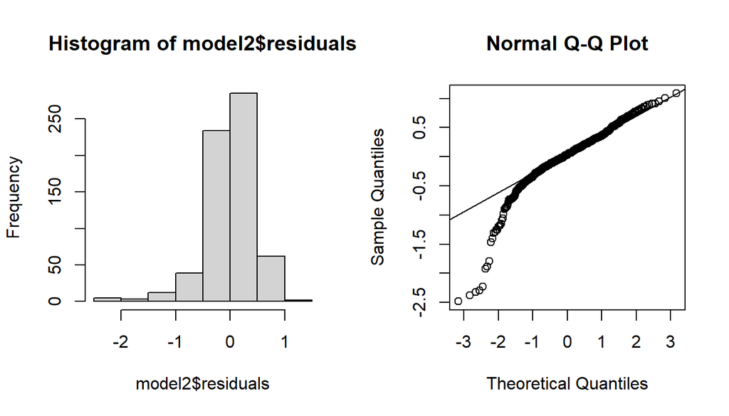

```r
# Setup 2 graphics in one row
par(mfrow=c(1,2))

# Histogram of the residuals
hist(model2$residuals)

# qqplot
qqnorm(model2$residuals)
qqline(model2$residuals)
```

That’s approximately normal. There is some skewness on the left side, but we are ok with it.

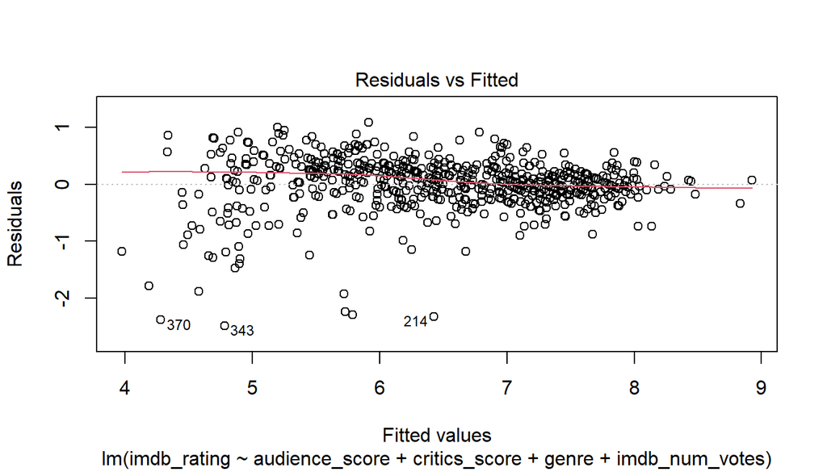

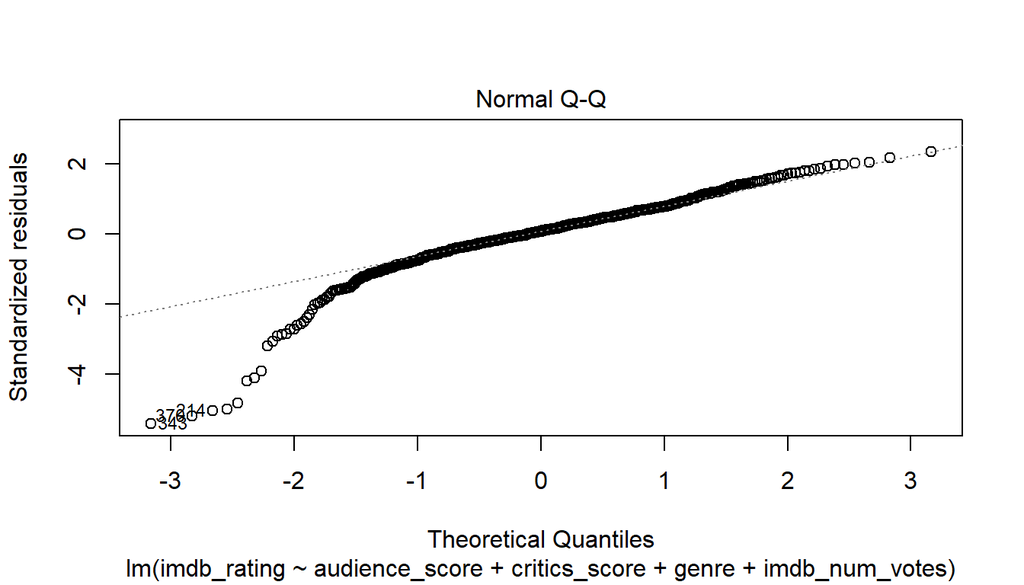

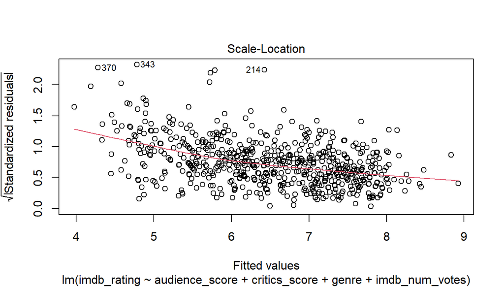

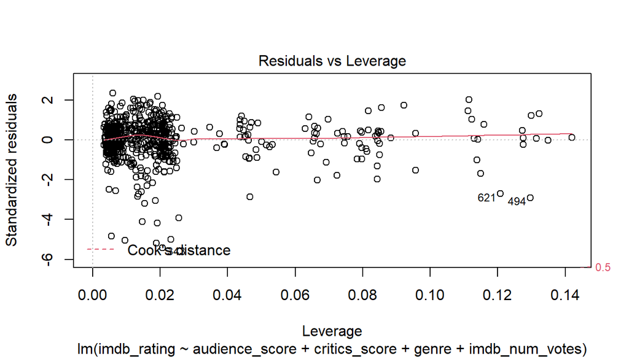

```r
plot(model2)
```

## Part 5: Prediction

```r
# Predictions
y_hat <- predict(model2)

performance = data.frame(title = movies2$title,
                         rating= movies2$imdb_rating,
                         prediction = y_hat,
                         y_error = movies2$imdb_rating - y_hat)

# RMSE
sqrt( mean(performance$y_error^2) )
```

```
## [1] 0.4576676
```

```r
# MAE
mae(performance$rating, performance$prediction)
```

```
## [1] 0.3182621
```

```r
# Get random predictions
preds_sample <- sample(1:nrow(performance), 15)

# View some predictions
performance[preds_sample,]
```

```
##                                   title rating prediction     y_error
## 2                              The Dish    7.3   7.475304 -0.17530423
## 400                              Meteor    4.9   4.333868  0.56613203
## 559                          Real Steel    7.1   7.085248  0.01475178
## 62                    Then She Found Me    6.0   5.802270  0.19773050
## 278          The Slumber Party Massacre    5.7   5.630352  0.06964828
## 470                The Science of Sleep    7.3   7.266204  0.03379566
## 311                             Maurice    7.8   7.615121  0.18487917
## 272 Politiki Kouzina (A Touch of Spice)    7.6   6.961086  0.63891371
## 563                            Mallrats    7.2   6.894901  0.30509905
## 191                       Married to It    5.9   5.521894  0.37810589
## 257                 The Devil's Rejects    6.9   6.940497 -0.04049707
## 280                            No Mercy    5.6   5.015157  0.58484275
## 266                          Funny Farm    6.1   5.903343  0.19665748
## 406 Tim and Eric's Billion Dollar Movie    5.3   5.499264 -0.19926357
## 635           Dead Men Don't Wear Plaid    6.8   7.191374 -0.39137439
```

## Part 6: Conclusion

Movie ratings are something subjective. What I like may not be the same as what you like. But having a lot of ratings from many people can show us some patterns that can be explained by the variables we have. From a dataset with 32 variables, we got to a final model with 4 variables, explaining more than 81% of the *imdb_ratings* variance. The model presented a 0.45 points error on average for each prediction and 0.32 of Mean Absolute error.